# Praca domowa 2

Miłosz Zieliński

## Dane

Dane wykorzystane w Pracy domowej 2 opisują wycenę nieruchmości. Każda obserwacja jest pewną nieruchmością, która posiada informacje takie jak powierzchnia, liczba pokoi, liczba łazienek i wiele więcj. Opis wszystkich kolumn w pliku `README.md`.

## Zadanie 1

Jak wygląda rozkład ceny nieruchomości w poszczególnych kodach pocztowych na przestrzeni lat? Rozważamy kody pocztowe, które mają więcej niż 280 posiadłości.

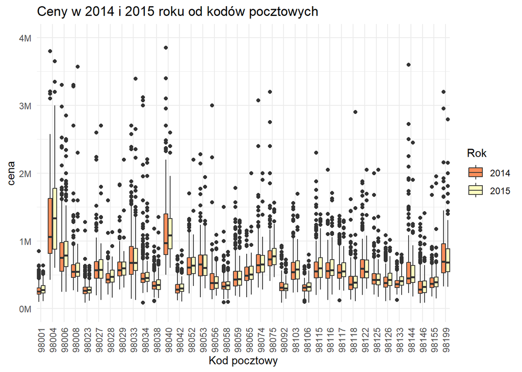

```r
kody <- df %>%
  group_by(zipcode) %>%
  summarise(counter = n()) %>%
  filter(counter >280)

df_1 <- df %>%
  filter(zipcode %in% kody$zipcode) %>%
  mutate(date = as.numeric(stringr::str_sub(date, 1, 4))) %>%
  select(date, zipcode, price) %>%
  ggplot(aes(x = as.factor(zipcode), y = price, fill = as.factor(date)))+
  geom_boxplot() +
  labs(x = "Kod pocztowy", y = "cena", fill = "Rok", title = "Ceny w 2014 i 2015 roku od kodów pocztowych") +
  theme_minimal() +
  scale_y_continuous(labels  = label_number(scale = 1e-6, suffix = "M"), limits = c(0, 4000000)) +
  scale_x_discrete(guide = guide_axis(angle = 90),expand = c(0,0))+
  scale_fill_brewer(palette = "Spectral")

df_1
```

**Komentarz:** W przedstawieniu danych uciąłem pojedyncze nieruchomości, aby grafika była bardziej czytelna. Można zauważyć, że dla zdecydowanej większości obszarów mediana ceny w 2015 roku jest wyższa niż w 2014 roku. Najdroższe wystawione nieruchomości występowały w obszarach o kodach 98004 oraz 98040, natomiast najtańsze to obszry o kodach 98001, 98023, 98042 oraz 98146. Użycie boxplot-ów pozwala dobrze porównać dwa kolejne lata, dlatego ich użyłem.

## Zadanie 2

Czy jest różnica w rozkładzie ceny nierchomości od powierzchni mieszkalnej uwzględniając podział na nieruchomości z piwnicą i bez?

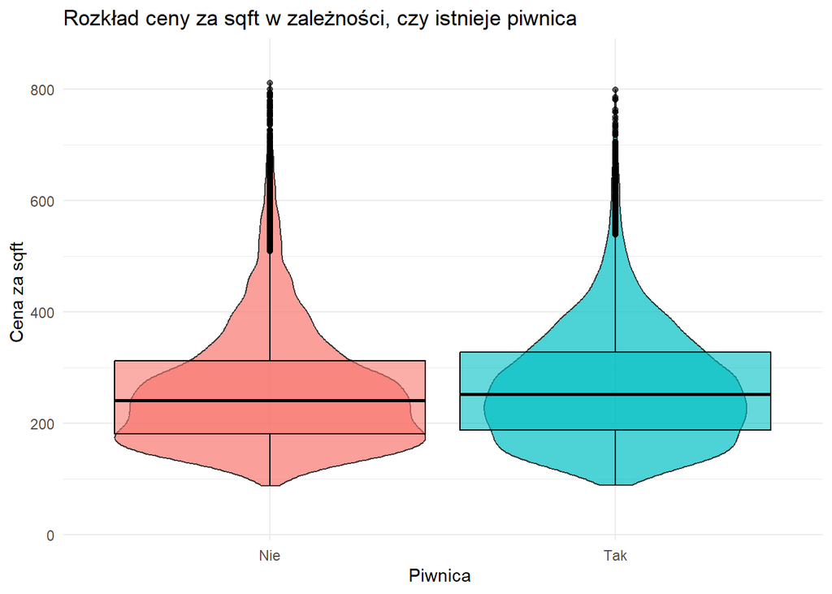

```r
df_2 <- df %>%
  mutate(basement = ifelse(sqft_basement > 0, "Tak", "Nie"), price_per_sqft = price/sqft_living) %>%
  ggplot( aes(x = basement, y = price_per_sqft,fill = basement)) +
  geom_violin(alpha = 0.7 ,show.legend = FALSE)+
  geom_boxplot(width = 0.9, color = "black", alpha = 0.6,show.legend = FALSE)+
  labs(title = "Rozkład ceny za sqft w zależności, czy istnieje piwnica",
       x = "Piwnica ",
       y = "Cena za sqft ",
       color = "Piwnica") +
  scale_y_continuous(limits = c(30,850))+
  theme_minimal()

df_2
```

**Komentarz:** Jest niewielka różnica w rozkłądzie cen. Możemy zauważyć, że mediana ceny mieszkań posiadających piwnicę jest nieznacznie wyższa od tych, które jej nie posiadają. Nie porównywałem tu bezpośdrenio ceny nieruchomości od powierzchni mieszkalnej, rozpatruję tu cenę za stopę kwadratową. Myslę, że to pozytywnie wpłwa na czytelność i wyciągnięcie wniosków.

## Zadanie 3

Jaka jest zależność pomiędzy jakością wykończenia nieruchomości a liczbą pięter?

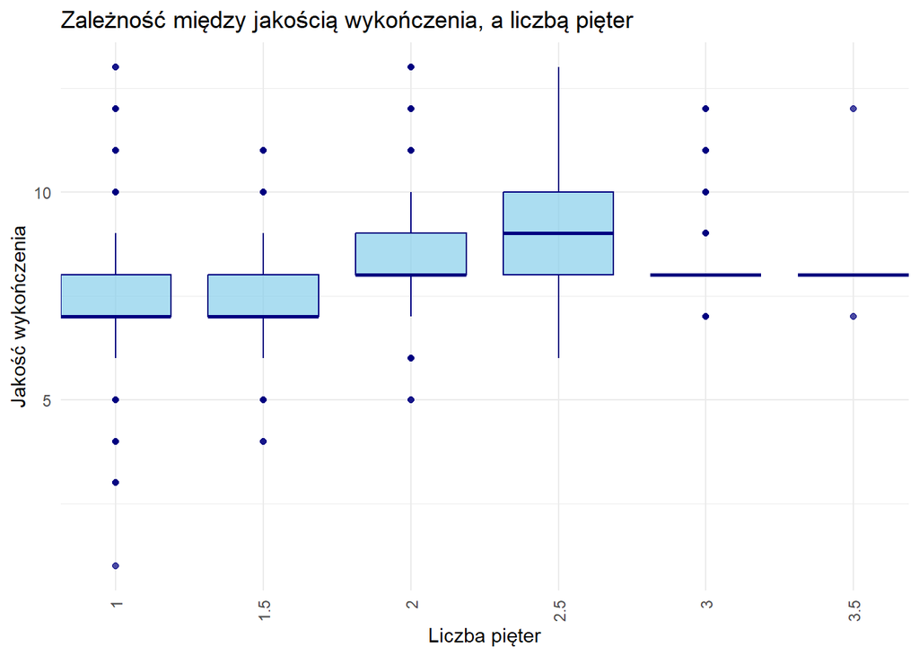

```r
df_3 <- ggplot(df, aes(x = as.factor(floors), y = grade)) +
  geom_boxplot(fill = "skyblue", color = "navyblue", alpha = 0.7) +
  labs(title = "Zależność między jakością wykończenia, a liczbą pięter",
       x = "Liczba pięter",
       y = "Jakość wykończenia") +
  theme_minimal() +
  scale_x_discrete(guide = guide_axis(angle = 90),expand = c(0,0))
df_3
```

**Komentarz:** W przypadku, gdy nieruchomość jest na piętrze 2.5:), to mediana jakości wykończenia jest największa, wynosi 9, czyli budynki z tyloma piętrami są najlepiej wykonane. Najniższą medianą natomiast cechują się budynki 1 i 1.5 -piętrowe. 1-piętrowe budynki mają także największy rozrzut oceny jakości wykończenia. W pozostałych przypadkach mediana kształtuje się na poziomie 8.

## Zadanie 4

Jaka jest zależność między powierzchnią mieszkalną nieruchomości a powierzchnią gruntu w podziale na liczbę sypialni?

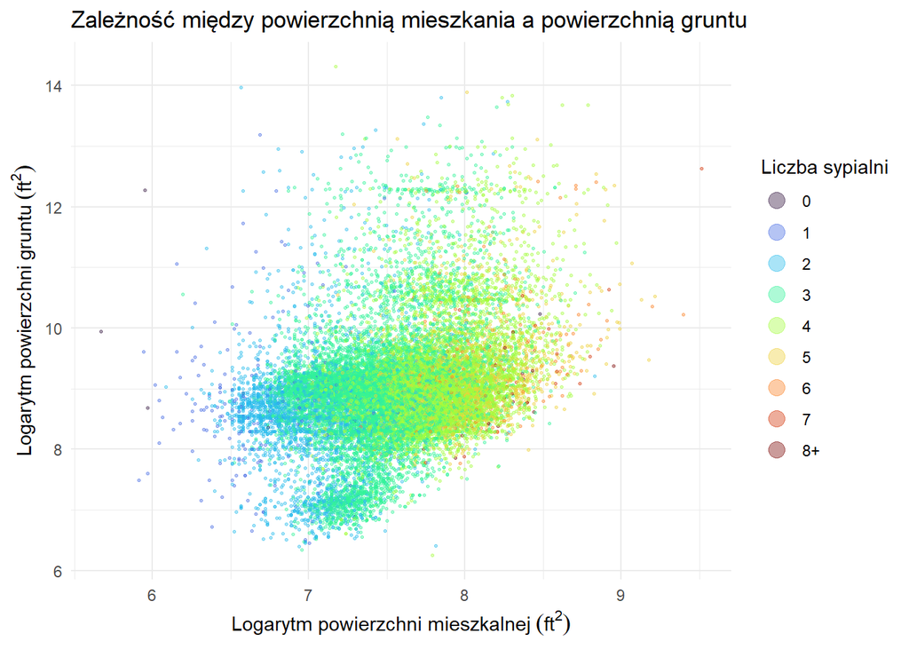

```r
df_4 <- df %>%
  mutate(bedroom_category = ifelse(bedrooms >= 8, "8+ ", as.character(bedrooms)))

ggplot(df_4, aes(x = log(sqft_living), y = log(sqft_lot), color = bedroom_category)) +
  geom_point(alpha = 0.4, size = 0.5) +
  labs(title = "Zależność między powierzchnią mieszkania a powierzchnią gruntu",
       x = expression("Logarytm powierzchni mieszkalnej"~(ft^2)),
       y = expression("Logarytm powierzchni gruntu"~(ft^2)),
       color = "Liczba sypialni") +
  theme_minimal() +
  scale_color_viridis_d(option = "H")+
  guides(color = guide_legend(override.aes = list(size = 4)))
```

**Komentarz:** Zdecydowałem się na takie stworzenie wykresu, ponieważ w czytelny sposób pokazuje on pewną zależność, pomimo trudności z odczytaniem poszczególnych wartości. Na wykreście przedstawione są obiekty, których powierzchnia mieszkalna, jak i powierzchnia gruntu zostały zlogarytmowane, dzięki czemu wykres jest czytelniejszy. Patrząc na wykres można zauważyć, że dla większości liczby sypialni, im większa powierzchnia mieszkania tym większa powierzchia gruntu, jednak nie jest to silna zaleźność. Zdecydowanie jednak widać, z im większa liczba sypialnii, tym większa powierzchnia mieszkalna i trochę większa powierzchnia gruntu.

## Zadanie 5

Rozważmy tylko nieruchomości, które miały remont. W której dekadzie było najwięcej przeprowadzonych remontów? Czy w poszczególnych dekadach jest porównywalny procent nieruchmości dla każdej wartości miary jakości i wykończenia nieruchomości?

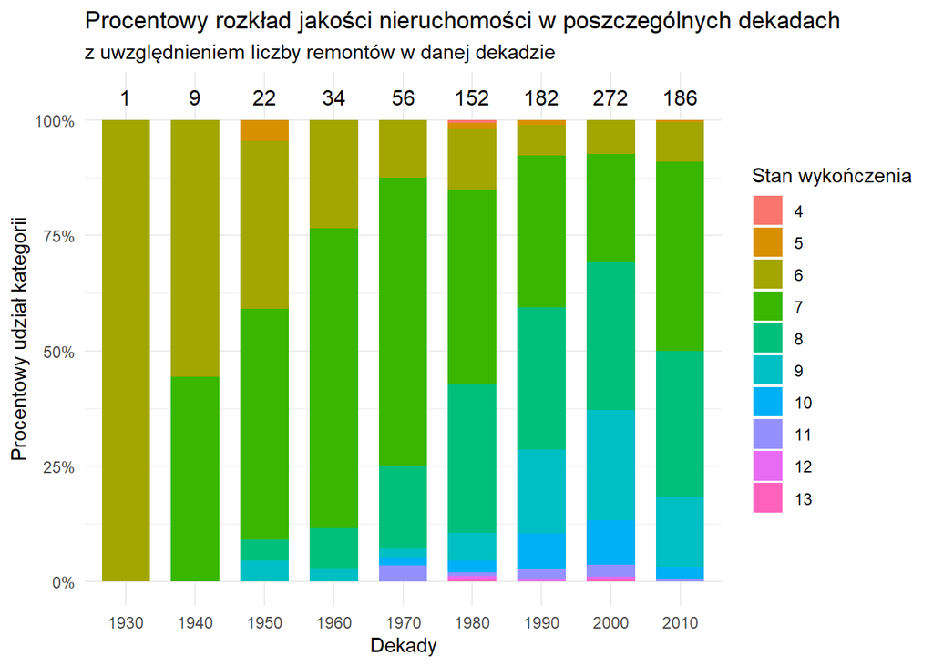

```r
df_5 <- df %>%
  filter(yr_renovated != 0) %>%
  mutate(decade = floor(yr_renovated / 10) * 10, condition = factor(grade, levels = c("13","12","11","10","9","8","7","6","5","4")))


decade_summary <- df_5 %>%
  group_by(decade, grade) %>%
  summarise(count = n(), .groups = 'drop') %>%
  mutate(percent = count / sum(count) * 100)

total_count <- decade_summary %>%
  group_by(decade) %>%
  summarise(total_count = sum(count))

ggplot( decade_summary, aes(x = as.factor(decade), y = percent, fill = as.factor(grade))) +
  geom_bar(stat = "identity", position = "fill", width = 0.7)  +
  geom_text(data = total_count, aes(x = as.factor(decade), y = 1.05, label = total_count),size = 4, inherit.aes = FALSE) +
  labs(title = "Procentowy rozkład jakości nieruchomości w poszczególnych dekadach ",
       subtitle = "z uwzględnieniem liczby remontów w danej dekadzie",
       x = "Dekady",
       y = "Procentowy udział kategorii",
       fill = "Stan wykończenia") +
  theme_minimal() +
  scale_y_continuous(labels = percent_format(scale = 100), expand = c(0.05,0))
```

**Komentarz:** Z wykresu możemy odczytać (wartości nad kolumnami), że największą liczbę remontów przeprowadzono w latach 2000-2009, były to 272 remonty. Możemy też zauważyć, że procenty miary jakości i wykończeńczenia nieruchomości nie sa porównywalne. Wraz ze wzrostem dekad rośnie procent nieruchomości, których ocena to 8 i więcej, osiągając szczyt w pierwszej dekadzie XXI wieku. Na przestrzeni dekad systematycznie malał procent niskich ocen, jednak jedynym wyjątkiem jest tu druga dekada XXI wieku, gdzie znacząco wzrósł procent nieruchomości z oceną 7, co wraz z niewieloma miarami wysokich ocen sprawiło, że wyjątkowo można porównać tę dekadę do lat. 80.

## Zadanie 6

Jak prezentuje się wartość minimalna, średnia i maksymalna ceny nieruchmości w podziele na rok budowy nieruchomości.

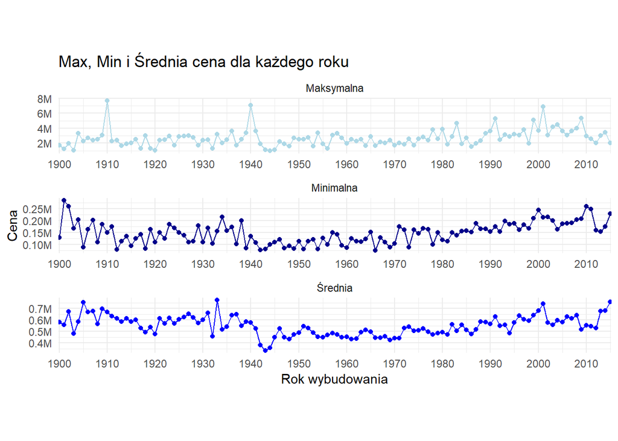

```r
df_6 <- df %>%
  group_by(yr_built) %>%
  summarise(Minimalna = min(price), Średnia = mean(price), Maksymalna = max(price)) %>%
  pivot_longer( cols = c(Minimalna, Maksymalna, Średnia), names_to = "type", values_to = "value") %>%
  ggplot(aes(x = yr_built, y = value, color = type)) +
  geom_point(size = 1.5) +
  geom_line(size = 0.5) +
  facet_wrap(~type, scales = "free",ncol=1) +
  labs(title = "Max, Min i Średnia cena dla każdego roku",
       x = "Rok wybudowania", y = "Cena") +
  scale_color_manual(values = c("Minimalna" = "darkblue", "Maksymalna" = "lightblue", "Średnia" = "blue"))+
  theme_minimal() +
  scale_x_continuous(breaks = seq(1900, 2015, by = 10), expand = c(0, 0.2))+
  scale_y_continuous(labels  = label_number(scale = 1e-6, suffix = "M"))+
  theme(legend.position = "none", aspect.ratio = 0.1)
df_6
```

**Komentarz:** Największe różnice procentowe pomiędzy latami budowy widać przy wartości maksymalnej. Najmniejsze natomiast widać przy wartości średniej. Największe ceny maksymalne występowały przy latach 1910, 1940 oraz 2001. Nie jest to powiązane z największymi wartościami ceny minimalnej, które to występowały przy latach 1901, 2010. Wartości ceny maksymalnej zawze są kilkukrotnie lub kilkunastokrotnie większe zarówno od ceny minimalnej jak i średniej. Podział na 3 osobne wykresy zdecydowanie poprawił czytelność danych. Gdy były one na jednym wykresie, to wartości dla średniej i minimalnej wyglądały prawie jak stałe.